# Classification Prediction Problem

Data Science 3 with R (STAT 301-3)

Author

Lucy Zhang

## Github Repo Link

**Github Link for Replication**

https://github.com/STAT301-3-2023SP/prediction-classification-Princess-gan.git

## Introduction

This Kaggle prediction problem aims at predicting results for a classification problem using a masked financial dataset. The metric used for evaluation is ROC_AUC (Receiver Operating Characteristic Area Under the Curve).

In this memo, I will describe the preprocessing process including feature engineering, the model tuning process, and finally predicting the outcome variable and evaluate it.

## Feature Engineering Processes

**Resampling Method:** I used cross-validation resampling method to create 5 folds and 3 repeats for the cleaned training dataset (factoring all the character variables).

## Model Tuning

After preprocessing steps and creating recipes, I fit and tuned **4** models, including random forest, K-Nearest Neighbors (KNN), Multivariate Adaptive Regression Splines (MARS), Multilayer Perceptron/Neural network (MLP).

I tuned the models using resampling method to find the best hyper parameters. The table below lists each model, and the corresponding Area Under Curve, and computation time after feeding in the training data.

| wflow_id | roc_auc | runtime |
| --- | --- | --- |
| mlp | 0.6252116 | 601.106 |
| rand_forest | 0.6154545 | 732.220 |
| mars | 0.6090970 | 84.377 |
| knn | 0.5542015 | 365.002 |

The following graph shows the Area Under Curve(`roc_auc`) value for models’ performance on training data:

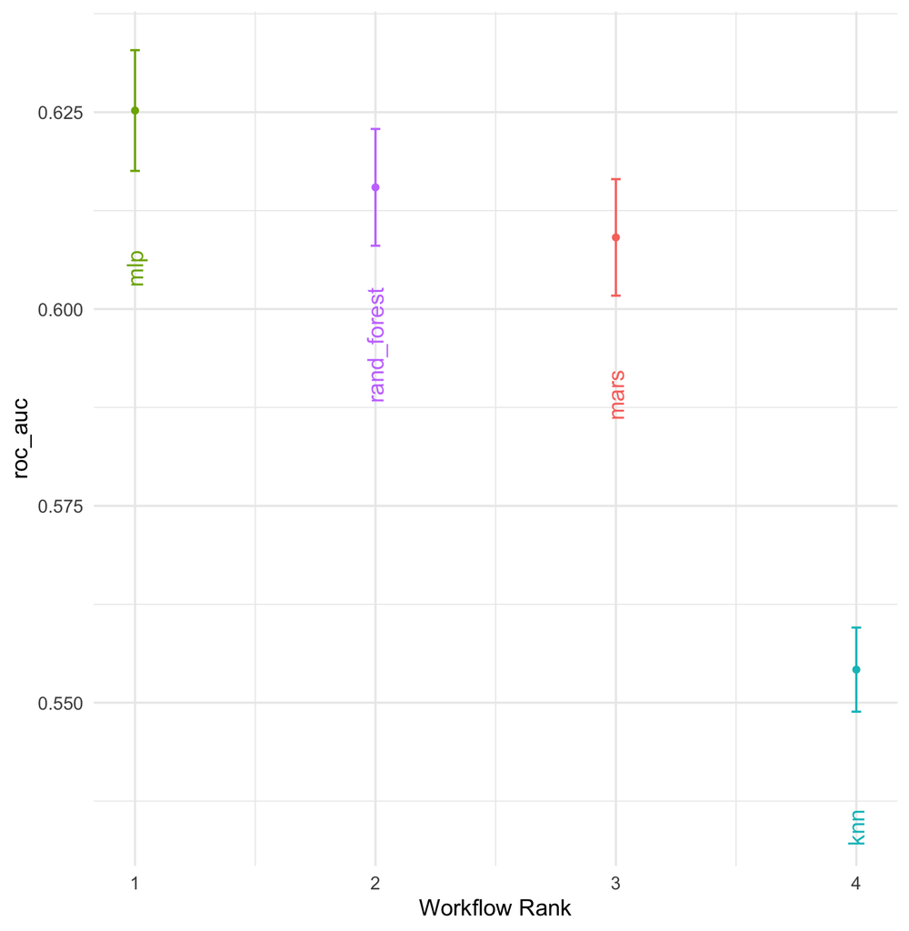

## Winner models:

The 2 selected models with the highest roc_auc values for the test data prediction vary a little different from the metric performance for training data. They are the MARS and Random Forest model.

## Runner-Up Model: Random Forest

The second best model, random forest model, is an ensemble learning method that combines the predictions of multiple decision trees to make more accurate predictions. After the tuning process, the selected best performing hyperparameters are 15 mtry (the number of variables randomly sampled as candidates at each split) and 30 min_n (the minimum number of samples required to split a node).

The final Area Under Curve(roc_auc) value after test data prediction is `0.5847`.

## Best Model: MARS

The best model is the MARS (Multivariate Adaptive Regression Splines) model. The selected hyper paramters within the model after tuning process are 12 num_terms (the maximum number of terms allowed in the model) and 1 prod_degree (the maximum product degree allowed in the model).

It achieved an Area Under Curve value of `0.5856`.